# Houston Heat - Heat Related Illness Prevention

April 15, 2026

Author

Andrea Reed & Kimberly Williams

```r
library(tidyverse)
library(sf)        # shapefile --> a set of files that work together
library(sfdep)     # Chloropleth Map and Moran's I
library(spmodel)   # spautor model
library(viridis)   # colorblind friendly colors
library(patchwork) # put graphs together
```

You have been contracted by the Houston Health Department as a junior data analyst. The city is increasingly concerned about the impact of heat on public health (it’s Houston after all) — especially among vulnerable populations. Your team’s mission is to analyze public health data related to **heat related deaths** in Houston and identify the key contributing factors. Your findings will help shape public awareness campaigns and guide local policy decisions.

## Data

```r
broken_dat <- st_read("Data/HoustonHeat.shp")  # sf object
dat <- st_make_valid(broken_dat)
clean <- dat |> filter(Population > 0)
```

Variables:

- Geometry - Coordinate info for the corresponding Houston census block groups
- Count - The number of heat-related illnesses reported last summer
- Population - The population of the census block
- NOAC - % of census block with no air conditioning
- MED_AGE - Median age of people in census block
- HispanicPC - % of Hispanic individuals in block
- BlackPCT - % of Black individuals in block
- under5PCT - % of individuals under age of 5 in block
- over65PCT - % of individuals over age 65 in block
- povertyPCT - % of individuals in poverty in block
- alonePCT - % of individuals in block who live alone
- MinTemp - Average daily minimum temperature last summer

Your objective is to analyze the data to identify contributing factors to heat-related illnesses as well as visualize high-risk areas across the greater Houston area. Your deliverable for this project is a 1-page (8.5x11 sheet) public-facing health flyer for a general audience, with insights or safety tips drawn from your analysis. Your flyer must contain the following:

- A model-based map of high and low risk areas across the city (not just the raw data)
- A list of factors that (significantly) contribute to increased or decreased risk (note that there are racial factors in here and this is a public-facing flyer so be sensitive and avoid harmful stereotypes)
- Suggestions on how to stay safe

If you don’t know what a flyer might look like, go to images.google.com and search something like “public health flyer for heat related illness” and you’ll get the idea. Canva is a great place to start with templates. Upload a PDF of flyer to gradescope.

```r
count0 <- clean |>
  filter(Count == 0)
nrow(count0)
```

```
[1] 411
```

```r
nrow(clean)
```

```
[1] 1482
```

```r
nrow(dat)
```

```
[1] 1487
```

## Calculate Relative Risk, and transform for normalcy

```r
# 1: filter out infinitives or NA (blocks without counts)
# R2: 0.09730984
RRdat1 <- clean |>
  mutate(RR = Count / (Population*(sum(Count)/sum(Population)))) |>
  mutate(log_RR = log(RR)) |>
  filter(is.finite(log_RR))
RRdat1_1 <- dat |> # basically the same thing, # R2:
  mutate(RR = if_else(Population == 0 | Count == 0, 0,
                      Count/(Population*(sum(Count)/sum(Population)))),
         log_RR = log(RR)) |>
  filter(is.finite(log_RR))

# 2: filter out counts first
# R2: 0.09730984
RRdat2 <- clean |>
  filter(Count > 0) |>
  mutate(RR = Count / (Population * (sum(Count) / sum(Population)))) |>
  mutate(log_RR = log(RR))

# 3: add small constant to account for areas without any heat incidents
# R2: 0.09189094
RRdat3 <- clean |>
  mutate(RR = (Count + 0.5) / (Population * (sum(Count) / sum(Population)))) |>
  mutate(log_RR = log(RR))

# 4: add constant of 1
# R2: 0.1130247
RRdat4 <- clean |>
  mutate(RR = (Count + 1) / (Population * (sum(Count) / sum(Population)))) |>
  mutate(log_RR = log(RR))

# 5: add constant of 0.9, remove MED_AGE to account for multicolinearity (high VIF)
# R2: 0.1110624
RRdat5 <- clean |>
  select(-MED_AGE) |>
  mutate(RR = (Count + 0.9) / (Population * (sum(Count) / sum(Population)))) |>
  mutate(log_RR = log(RR))
```

```r
RRdat <- RRdat4 # determine pick here!!
```

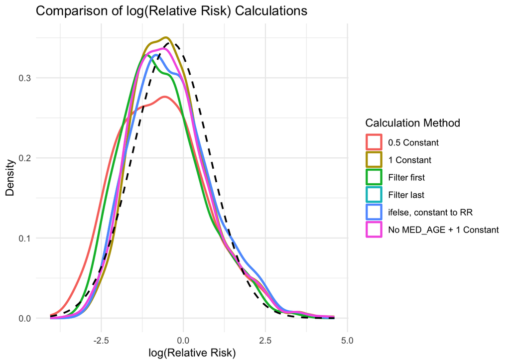

```r
combined_dat <- bind_rows(
  RRdat1 %>% mutate(Version = "Filter last"),
  RRdat2 %>% mutate(Version = "Filter first"),
  RRdat3 %>% mutate(Version = "0.5 Constant"),
  RRdat4 %>% mutate(Version = "1 Constant"),
  RRdat5 %>% mutate(Version = "No MED_AGE + 1 Constant"),
  RRdat1_1 %>% mutate(Version = "ifelse, constant to RR")
)

ggplot(combined_dat, aes(x = log_RR)) +
  geom_density(aes(color = Version), linewidth = 1, alpha = 0.5) +
  stat_function(fun = dnorm,
                args = list(mean = mean(RRdat$log_RR, na.rm = TRUE),
                            sd = sd(RRdat$log_RR, na.rm = TRUE)),
                linetype = "dashed", color = "black", linewidth = 0.8) +
  theme_minimal() +
  labs(
    title = "Comparison of log(Relative Risk) Calculations",
    x = "log(Relative Risk)",
    y = "Density",
    color = "Calculation Method"
  )
```

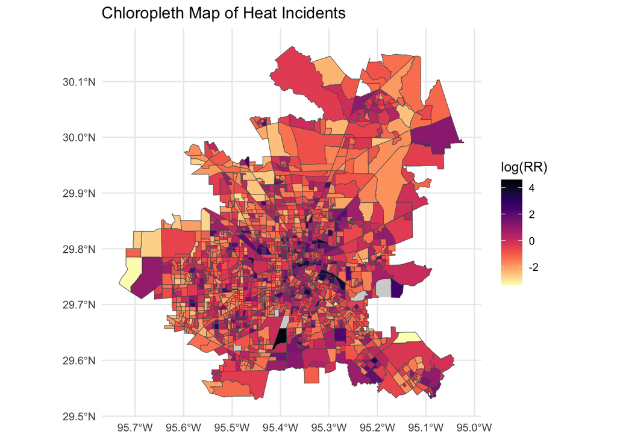

```r
ggplot(data=RRdat, mapping=aes(fill=log_RR)) +
  geom_sf(data = dat, fill = "lightgrey", color = "white") + # Background (all tracts)
  scale_fill_viridis(option = "magma", direction = -1) +
  theme_minimal() +
  geom_sf() +
  labs(title = "Chloropleth Map of Heat Incidents",
       fill = "log(RR)")
```

```r
model_formula <- log_RR ~ NOAC + HispanicPC + BlackPCT +
                 under5PCT + over65PCT + povertyPCT + alonePCT + MinTemp
car_model <- spautor(model_formula,
                     data = RRdat,
                     spcov_type="car") # Conditional Autoregressive

resids = resid(car_model)
decorr_resid = rstandard(car_model)
fitted = fitted.values(car_model)

RRdat_fr <- RRdat |>
  mutate(resids = resids, decorr_resid = decorr_resid, fitted = fitted)
```

```r
car::vif(lm(model_formula, data = RRdat))
```

```
      NOAC HispanicPC   BlackPCT  under5PCT  over65PCT povertyPCT   alonePCT
  2.384051   3.423552   2.367592   2.162400   1.520412   2.492086   1.455633
   MinTemp
  1.383413
```

# LINE assumptions from CAR model

### Linearity

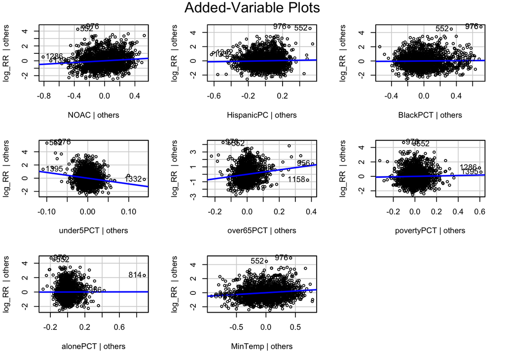

```r
rrlm <- lm(model_formula, data = RRdat)
car::avPlots(rrlm)
```

### Independence

```r
moran_test <- RRdat %>%
  st_contiguity() %>% #Extract the neighbors of each observation
  global_moran_test(x=decorr_resid, #Variable we are looking at
                    nb=.,
                    wt=st_weights(.))
moran_test
```

```
    Moran I test under randomisation

data:  x
weights: listw

Moran I statistic standard deviate = 0.9303, p-value = 0.1761
alternative hypothesis: greater
sample estimates:
Moran I statistic       Expectation          Variance
     0.0132324790     -0.0006752194      0.0002234921
```

Nice it’s independent

### Normality

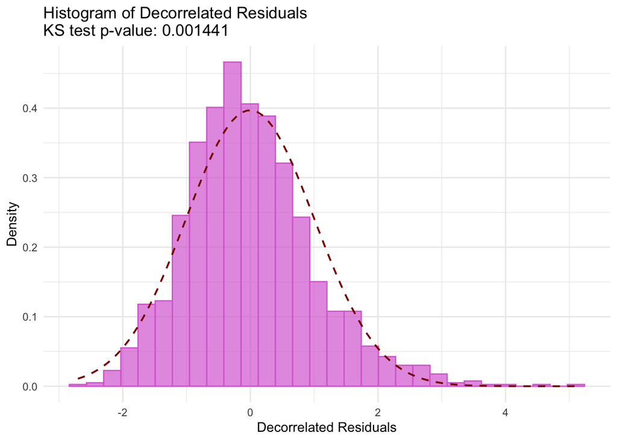

```r
ks <- ks.test(decorr_resid, "pnorm", mean=0, sd=1)
pval <- formatC(ks$p.value, digits = 4)

hr <- ggplot(data.frame(resids = decorr_resid), aes(x = resids)) +
  geom_histogram(aes(y = after_stat(density)), bins = 30, fill = "orchid",
                 alpha = 0.7, color = "orchid") +
  stat_function(fun = dnorm, args = list(mean = mean(decorr_resid),
                                         sd = sd(decorr_resid)),
                linewidth = 0.7, color = "darkred", linetype = "dashed") +
  labs(title = paste0("Histogram of Decorrelated Residuals",
                      "\nKS test p-value: ", pval),
       x = "Decorrelated Residuals",
       y = "Density") +
  theme_minimal()
hr
```

3 is normal, 4 is almost normal 0.0014, 5 almost 0.00345

### Equal Variance

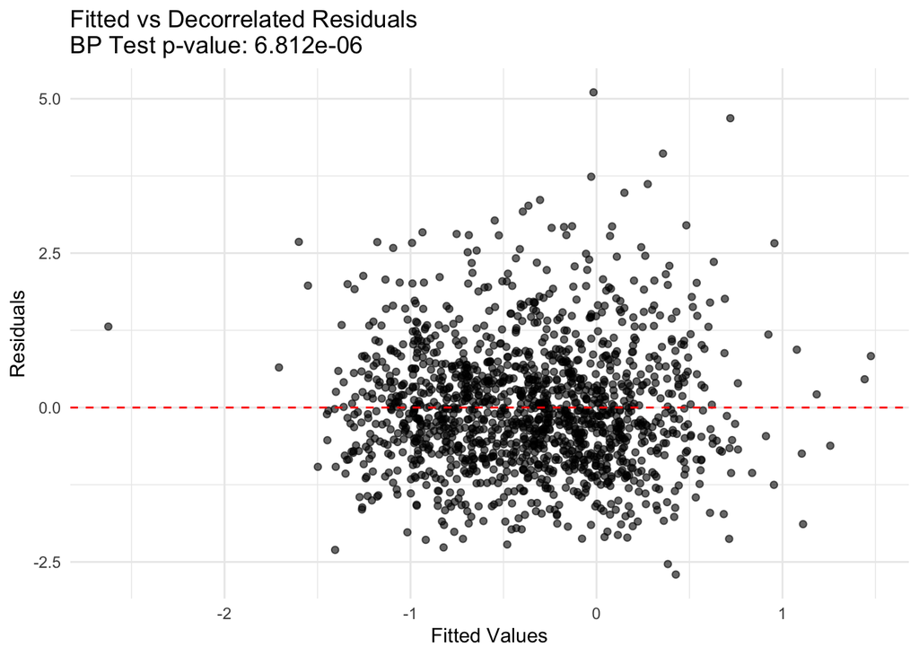

```r
bp_test <- lmtest::bptest(
  decorr_resid ~ log_RR,
  data = RRdat
)
bp_pval <- formatC(bp_test$p.value, digits = 4)

fr <- ggplot(data.frame(fitted = fitted, resid = decorr_resid),
       aes(x = fitted, y = decorr_resid)) +
  geom_point(alpha = 0.6) +
  geom_hline(yintercept = 0, linetype = "dashed", color = "red") +
  labs(x = "Fitted Values",
       y = "Residuals",
       title = paste0("Fitted vs Decorrelated Residuals\n",
                    "BP Test p-value: ", bp_pval)) +
  theme_minimal()
fr
```

```r
pseudoR2(car_model)
```

```
[1] 0.1130247
```

A pseudo-$R^2$ value of 0.1130247 means that roughly 11.3% of the variability in log(Relative Risk) can be explained by the car model.

```r
summary(car_model)
```

```
Call:
spautor(formula = model_formula, data = RRdat, spcov_type = "car")

Residuals:
    Min      1Q  Median      3Q     Max
-2.5998 -0.7934 -0.1428  0.6462  4.6303

Coefficients (fixed):
              Estimate Std. Error z value Pr(>|z|)
(Intercept) -15.111934   3.889606  -3.885 0.000102 ***
NOAC          0.630992   0.189827   3.324 0.000887 ***
HispanicPC    0.111916   0.227045   0.493 0.622068
BlackPCT     -0.009301   0.189891  -0.049 0.960936
under5PCT    -9.858023   1.522948  -6.473 9.61e-11 ***
over65PCT     2.938622   0.534140   5.502 3.76e-08 ***
povertyPCT    0.219725   0.323925   0.678 0.497568
alonePCT     -0.220380   0.348894  -0.632 0.527614
MinTemp       0.605770   0.157128   3.855 0.000116 ***
---
Signif. codes:  0 '***' 0.001 '**' 0.01 '*' 0.05 '.' 0.1 ' ' 1

Pseudo R-squared: 0.113

Coefficients (car spatial covariance):
    de  range
5.9224 0.8362
```

```r
# reduced model
reduced <- log_RR ~ NOAC + under5PCT + over65PCT + MinTemp
car2 <- spautor(reduced,
                data = RRdat,
                spcov_type="car") # Conditional Autoregressive
summary(car2)
```

```
Call:
spautor(formula = reduced, data = RRdat, spcov_type = "car")

Residuals:
    Min      1Q  Median      3Q     Max
-2.6184 -0.7998 -0.1461  0.6348  4.6527

Coefficients (fixed):
            Estimate Std. Error z value Pr(>|z|)
(Intercept) -15.3592     3.7742  -4.070 4.71e-05 ***
NOAC          0.7125     0.1641   4.342 1.41e-05 ***
under5PCT    -8.9117     1.2764  -6.982 2.91e-12 ***
over65PCT     2.8580     0.5058   5.650 1.60e-08 ***
MinTemp       0.6144     0.1521   4.041 5.33e-05 ***
---
Signif. codes:  0 '***' 0.001 '**' 0.01 '*' 0.05 '.' 0.1 ' ' 1

Pseudo R-squared: 0.113

Coefficients (car spatial covariance):
    de  range
5.9464 0.8268
```

```r
lmtest::lrtest(car_model, car2)
```

```
Likelihood ratio test

Model 1: log_RR ~ NOAC + HispanicPC + BlackPCT + under5PCT + over65PCT +
    povertyPCT + alonePCT + MinTemp
Model 2: log_RR ~ NOAC + under5PCT + over65PCT + MinTemp
  #Df  LogLik Df Chisq Pr(>Chisq)
1   2 -2155.8
2   2 -2154.5  0 2.494  < 2.2e-16 ***
---
Signif. codes:  0 '***' 0.001 '**' 0.01 '*' 0.05 '.' 0.1 ' ' 1
```

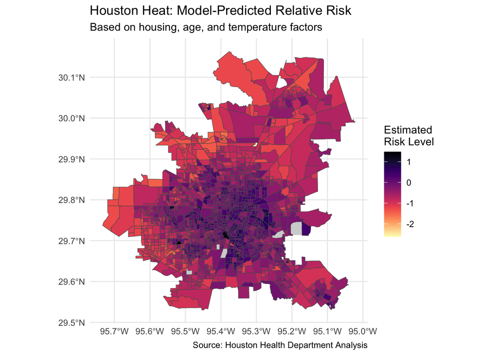

```r
# Plotting the model-based risk map
ggplot(data = RRdat_fr) +
  geom_sf(data = dat, fill = "lightgrey", color = "white") + # Use a neutral background for census blocks with no data
  geom_sf(aes(fill = fitted)) + # Map the 'fitted' values to the fill color
  scale_fill_viridis(option = "magma", direction = -1, name = "Estimated\nRisk Level") +
  theme_minimal() +
  labs(
    title = "Houston Heat: Model-Predicted Relative Risk",
    subtitle = "Based on housing, age, and temperature factors",
    caption = "Source: Houston Health Department Analysis"
  )
```